# New York BikeShare 2.0

### Explore Bike Share Data

For this project, your goal is to ask and answer three questions about the available bikeshare data from Washington, Chicago, and New York. This notebook can be submitted directly through the workspace when you are confident in your results.

You will be graded against the project [Rubric](https://review.udacity.com/#!/rubrics/2508/view) by a mentor after you have submitted. To get you started, you can use the template below, but feel free to be creative in your solutions!

```r
ny = read.csv('new_york_city.csv')
wash = read.csv('washington.csv')
chi = read.csv('chicago.csv')
```

```r
head(ny)
```

| X | Start.Time | End.Time | Trip.Duration | Start.Station | End.Station | User.Type | Gender | Birth.Year |
| --- | --- | --- | --- | --- | --- | --- | --- | --- |
| 5688089 | 2017-06-11 14:55:05 | 2017-06-11 15:08:21 | 795 | Suffolk St & Stanton St | W Broadway & Spring St | Subscriber | Male | 1998 |
| 4096714 | 2017-05-11 15:30:11 | 2017-05-11 15:41:43 | 692 | Lexington Ave & E 63 St | 1 Ave & E 78 St | Subscriber | Male | 1981 |
| 2173887 | 2017-03-29 13:26:26 | 2017-03-29 13:48:31 | 1325 | 1 Pl & Clinton St | Henry St & Degraw St | Subscriber | Male | 1987 |
| 3945638 | 2017-05-08 19:47:18 | 2017-05-08 19:59:01 | 703 | Barrow St & Hudson St | W 20 St & 8 Ave | Subscriber | Female | 1986 |
| 6208972 | 2017-06-21 07:49:16 | 2017-06-21 07:54:46 | 329 | 1 Ave & E 44 St | E 53 St & 3 Ave | Subscriber | Male | 1992 |
| 1285652 | 2017-02-22 18:55:24 | 2017-02-22 19:12:03 | 998 | State St & Smith St | Bond St & Fulton St | Subscriber | Male | 1986 |

```r
head(wash)
```

| X | Start.Time | End.Time | Trip.Duration | Start.Station | End.Station | User.Type |
| --- | --- | --- | --- | --- | --- | --- |
| 1621326 | 2017-06-21 08:36:34 | 2017-06-21 08:44:43 | 489.066 | 14th & Belmont St NW | 15th & K St NW | Subscriber |
| 482740 | 2017-03-11 10:40:00 | 2017-03-11 10:46:00 | 402.549 | Yuma St & Tenley Circle NW | Connecticut Ave & Yuma St NW | Subscriber |
| 1330037 | 2017-05-30 01:02:59 | 2017-05-30 01:13:37 | 637.251 | 17th St & Massachusetts Ave NW | 5th & K St NW | Subscriber |
| 665458 | 2017-04-02 07:48:35 | 2017-04-02 08:19:03 | 1827.341 | Constitution Ave & 2nd St NW/DOL | M St & Pennsylvania Ave NW | Customer |
| 1481135 | 2017-06-10 08:36:28 | 2017-06-10 09:02:17 | 1549.427 | Henry Bacon Dr & Lincoln Memorial Circle NW | Maine Ave & 7th St SW | Subscriber |
| 1148202 | 2017-05-14 07:18:18 | 2017-05-14 07:24:56 | 398.000 | 1st & K St SE | Eastern Market Metro / Pennsylvania Ave & 7th St SE | Subscriber |

```r
head(chi)
```

| X | Start.Time | End.Time | Trip.Duration | Start.Station | End.Station | User.Type | Gender | Birth.Year |
| --- | --- | --- | --- | --- | --- | --- | --- | --- |
| 1423854 | 2017-06-23 15:09:32 | 2017-06-23 15:14:53 | 321 | Wood St & Hubbard St | Damen Ave & Chicago Ave | Subscriber | Male | 1992 |
| 955915 | 2017-05-25 18:19:03 | 2017-05-25 18:45:53 | 1610 | Theater on the Lake | Sheffield Ave & Waveland Ave | Subscriber | Female | 1992 |
| 9031 | 2017-01-04 08:27:49 | 2017-01-04 08:34:45 | 416 | May St & Taylor St | Wood St & Taylor St | Subscriber | Male | 1981 |
| 304487 | 2017-03-06 13:49:38 | 2017-03-06 13:55:28 | 350 | Christiana Ave & Lawrence Ave | St. Louis Ave & Balmoral Ave | Subscriber | Male | 1986 |
| 45207 | 2017-01-17 14:53:07 | 2017-01-17 15:02:01 | 534 | Clark St & Randolph St | Desplaines St & Jackson Blvd | Subscriber | Male | 1975 |
| 1473887 | 2017-06-26 09:01:20 | 2017-06-26 09:11:06 | 586 | Clinton St & Washington Blvd | Canal St & Taylor St | Subscriber | Male | 1990 |

### Question 1: Does age influence the type of rider in New York?

```r
# Load packages
library(ggplot2)
```

```
       X                         Start.Time                   End.Time
 Min.   :     47   2017-05-11 18:26:10:    3   2017-01-03 08:54:10:    2
 1st Qu.:1712425   2017-01-04 13:58:24:    2   2017-01-04 17:21:55:    2
 Median :3418634   2017-01-09 09:36:01:    2   2017-01-05 17:25:17:    2
 Mean   :3415873   2017-01-21 15:36:56:    2   2017-01-12 08:34:01:    2
 3rd Qu.:5123382   2017-01-21 17:49:59:    2   2017-01-12 09:41:54:    2
 Max.   :6816152   2017-01-21 20:08:29:    2   2017-01-12 20:34:42:    2
                   (Other)            :54757   (Other)            :54758
 Trip.Duration                     Start.Station
 Min.   :     61.0   Pershing Square North:  592
 1st Qu.:    368.0   W 21 St & 6 Ave      :  385
 Median :    610.0   Broadway & E 22 St   :  383
 Mean   :    903.6   E 17 St & Broadway   :  380
 3rd Qu.:   1051.0   West St & Chambers St:  364
 Max.   :1088634.0   W 20 St & 11 Ave     :  329
 NA's   :1           (Other)              :52337
                End.Station         User.Type        Gender        Birth.Year
 Pershing Square North:  556             :    0         :    0   Min.   :1885
 E 17 St & Broadway   :  445   Customer  : 5558   Female:12159   1st Qu.:1970
 Broadway & E 22 St   :  427   Subscriber:49093   Male  :37201   Median :1981
 W 21 St & 6 Ave      :  365   NA's      :  119   NA's  : 5410   Mean   :1978
 W 20 St & 11 Ave     :  344                                     3rd Qu.:1988
 W 38 St & 8 Ave      :  338                                     Max.   :2001
 (Other)              :52295                                     NA's   :5218
```

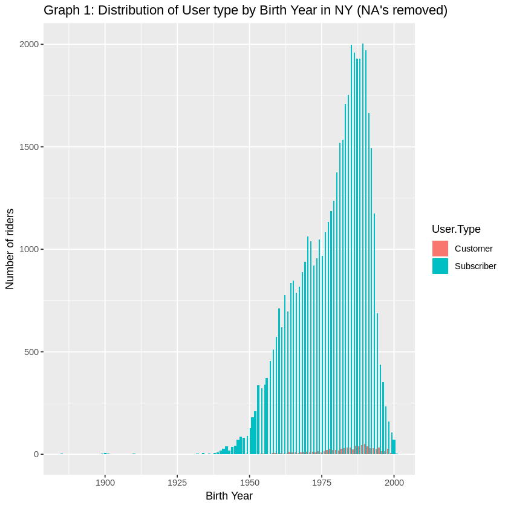

```
            Customer Subscriber
  1885    0        0          3
  1886    0        0          1
  1893    0        0          1
  1899    0        0          2
  1900    0        0          7
  1901    0        0          2
  1910    0        0          3
  1917    0        0          1
  1923    0        0          1
  1926    0        0          1
  1927    0        0          1
  1930    0        0          1
  1932    0        0          3
  1934    0        0          7
```

[output cut: 67 more lines]

```
ny2$User.Type:
NULL
------------------------------------------------------------
ny2$User.Type: Customer
   Min. 1st Qu.  Median    Mean 3rd Qu.    Max.
   1949    1978    1986    1984    1991    1999
------------------------------------------------------------
ny2$User.Type: Subscriber
   Min. 1st Qu.  Median    Mean 3rd Qu.    Max.
   1885    1970    1981    1978    1988    2001
```

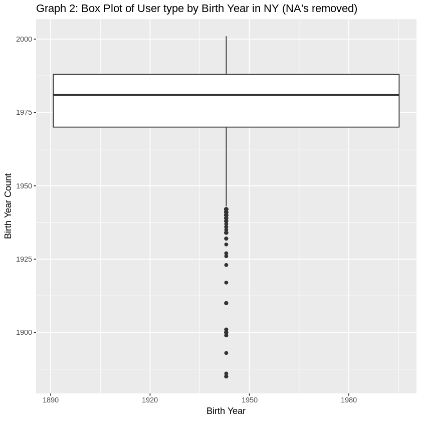

```r
# Look at a quick overview of the data before getting started
summary(ny)
#I can see a lot of nulls for the birthday and some nulls for user type. I will remove the NAs.


#Where blanks are equal to NA
ny$Birth.Year[ny$Birth.Year==""] <-NA
ny$User.Type[ny$User.Type ==""] <-NA
#Ploting distribution User type by birth year in New York.
#This is with the null values removed.
ny %>%
  filter(!is.na(Birth.Year) & !is.na(User.Type)) %>%
  ggplot(aes(x = Birth.Year, fill = User.Type))+
    geom_bar(position = "dodge") +
    ylab('Number of Riders') +
    xlab('Birth Year')+
    ggtitle("Graph 1: Distribution of User type by Birth Year in NY (NA's removed)")

# Box Plot of the Birth Year
ny %>%
  filter(!is.na(Birth.Year)) %>%
  ggplot(aes(x = Birth.Year, y = Birth.Year))+
    geom_boxplot()+
    ylab('Birth Year Count') +
    xlab('Birth Year')+
    ggtitle("Graph 2: Box Plot of User type by Birth Year in NY (NA's removed)")

# Table for no NUll values in the data set. This table is
ny2 <-ny %>%
  filter(!is.na(Birth.Year) & !is.na(User.Type))

table(ny2$Birth.Year, ny2$User.Type)

# Summary between the 2 groups
by(ny2$Birth.Year, ny2$User.Type, summary)
```

**The birth year with the most subscribers is roughly around 1988. There are less customers then subscribers. The peak of the riders are roughly in their 30s.**

### Question 2: Does Gender influence the type of rider in New York

```r
# Load packages
library(ggplot2)
```

```
       X                         Start.Time                   End.Time
 Min.   :     47   2017-05-11 18:26:10:    3   2017-01-03 08:54:10:    2
 1st Qu.:1712425   2017-01-04 13:58:24:    2   2017-01-04 17:21:55:    2
 Median :3418634   2017-01-09 09:36:01:    2   2017-01-05 17:25:17:    2
 Mean   :3415873   2017-01-21 15:36:56:    2   2017-01-12 08:34:01:    2
 3rd Qu.:5123382   2017-01-21 17:49:59:    2   2017-01-12 09:41:54:    2
 Max.   :6816152   2017-01-21 20:08:29:    2   2017-01-12 20:34:42:    2
                   (Other)            :54757   (Other)            :54758
 Trip.Duration                     Start.Station
 Min.   :     61.0   Pershing Square North:  592
 1st Qu.:    368.0   W 21 St & 6 Ave      :  385
 Median :    610.0   Broadway & E 22 St   :  383
 Mean   :    903.6   E 17 St & Broadway   :  380
 3rd Qu.:   1051.0   West St & Chambers St:  364
 Max.   :1088634.0   W 20 St & 11 Ave     :  329
 NA's   :1           (Other)              :52337
                End.Station         User.Type        Gender        Birth.Year
 Pershing Square North:  556             :    0         :    0   Min.   :1885
 E 17 St & Broadway   :  445   Customer  : 5558   Female:12159   1st Qu.:1970
 Broadway & E 22 St   :  427   Subscriber:49093   Male  :37201   Median :1981
 W 21 St & 6 Ave      :  365   NA's      :  119   NA's  : 5410   Mean   :1978
 W 20 St & 11 Ave     :  344                                     3rd Qu.:1988
 W 38 St & 8 Ave      :  338                                     Max.   :2001
 (Other)              :52295                                     NA's   :5218
```

```
               Customer Subscriber
             0        0          0
  Female     0      324      11804
  Male       0      491      36625
```

```
ny2$User.Type:
NULL
------------------------------------------------------------
ny2$User.Type: Customer
       Female   Male   NA's
     0    324    491   4743
------------------------------------------------------------
ny2$User.Type: Subscriber
       Female   Male   NA's
     0  11804  36625    664
```

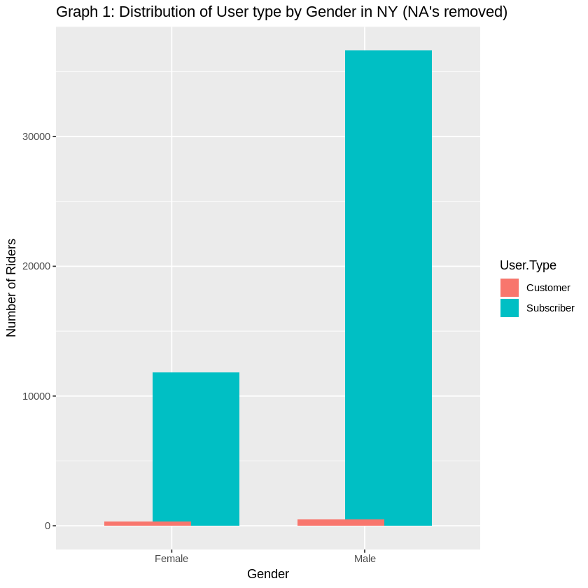

```r
# Look at a quick overview of the data before getting started
summary(ny)
#I can see a lot of nulls for the gender and some nulls for user types. I will remove the NAs.


#Where blanks are equal to NA
ny$Birth.Year[ny$Gender==""] <-NA
ny$User.Type[ny$User.Type ==""] <-NA
#Ploting distribution User type by birth year in New York.
#This is with the null values removed.
ny %>%
  filter(!is.na(Gender) & !is.na(User.Type)) %>%
  ggplot(aes(x = Gender, fill = User.Type))+
    geom_bar(position = position_dodge(width = 0.5)) +
    ylab('Number of Riders') +
    xlab('Gender')+
    ggtitle("Graph 1: Distribution of User type by Gender in NY (NA's removed)")



# Table for no NUll values in the data set. This table is
ny2 <-ny %>%
  filter(!is.na(User.Type) & !is.na(User.Type))

table(ny2$Gender, ny2$User.Type)

# Summary between the 2 groups
by(ny2$Gender, ny2$User.Type, summary)
```

**There are more males in this data set and most of the males are under the subscriber.**

### Question 3: Are the males or females in a certain age group?

```r
# Load packages
library(ggplot2)
```

```
       X                         Start.Time                   End.Time
 Min.   :     47   2017-05-11 18:26:10:    3   2017-01-03 08:54:10:    2
 1st Qu.:1712425   2017-01-04 13:58:24:    2   2017-01-04 17:21:55:    2
 Median :3418634   2017-01-09 09:36:01:    2   2017-01-05 17:25:17:    2
 Mean   :3415873   2017-01-21 15:36:56:    2   2017-01-12 08:34:01:    2
 3rd Qu.:5123382   2017-01-21 17:49:59:    2   2017-01-12 09:41:54:    2
 Max.   :6816152   2017-01-21 20:08:29:    2   2017-01-12 20:34:42:    2
                   (Other)            :54757   (Other)            :54758
 Trip.Duration                     Start.Station
 Min.   :     61.0   Pershing Square North:  592
 1st Qu.:    368.0   W 21 St & 6 Ave      :  385
 Median :    610.0   Broadway & E 22 St   :  383
 Mean   :    903.6   E 17 St & Broadway   :  380
 3rd Qu.:   1051.0   West St & Chambers St:  364
 Max.   :1088634.0   W 20 St & 11 Ave     :  329
 NA's   :1           (Other)              :52337
                End.Station         User.Type        Gender        Birth.Year
 Pershing Square North:  556             :    0         :    0   Min.   :1885
 E 17 St & Broadway   :  445   Customer  : 5558   Female:12159   1st Qu.:1970
 Broadway & E 22 St   :  427   Subscriber:49093   Male  :37201   Median :1981
 W 21 St & 6 Ave      :  365   NA's      :  119   NA's  : 5410   Mean   :1978
 W 20 St & 11 Ave     :  344                                     3rd Qu.:1988
 W 38 St & 8 Ave      :  338                                     Max.   :2001
 (Other)              :52295                                     NA's   :5218
```

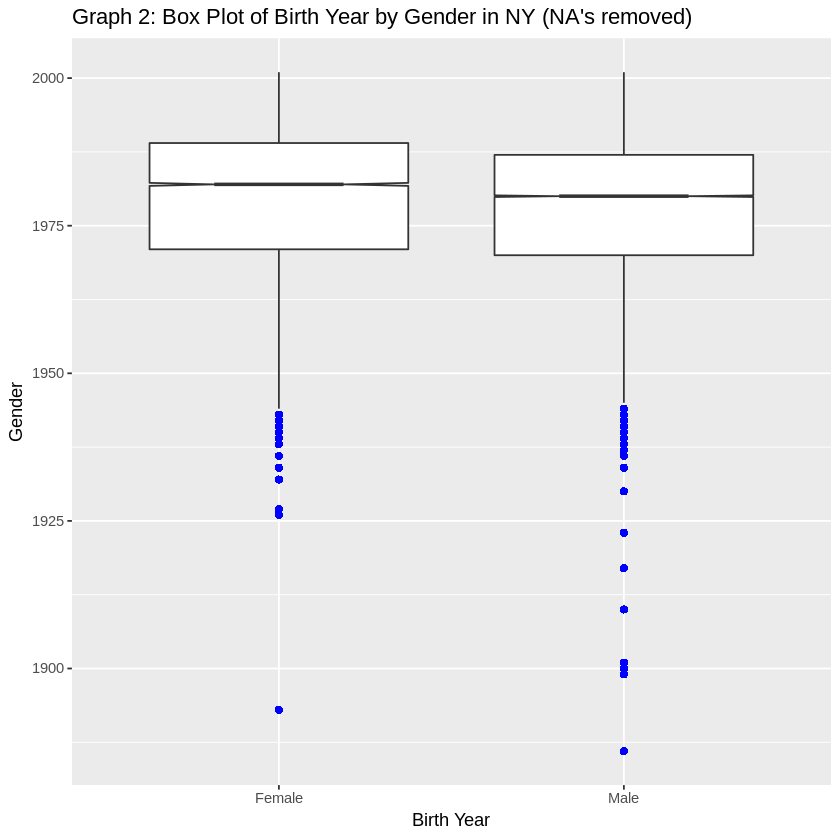

```r
# Look at a quick overview of the data before getting started
summary(ny)
#I can see a lot of nulls for the gender and some nulls for user types. I will remove the NAs.


#Where blanks are equal to NA
ny$Birth.Year[ny$Gender==""] <-NA
ny$User.Type[ny$Birth.Year ==""] <-NA

# Box Plot of the Birth Year
ny %>%
  filter(!is.na(Gender)) %>%
  ggplot(aes(x = Gender, y = Birth.Year))+
    geom_boxplot(outlier.colour="blue", outlier.shape=16, outlier.size=2, notch=TRUE)+
    ylab('Gender') +
    xlab('Birth Year')+
    ggtitle("Graph 2: Box Plot of Birth Year by Gender in NY (NA's removed)")
```

**Looking at the box plot, I see that females in this data set are slightly under than the males.**

## Finishing Up

> Congratulations! You have reached the end of the Explore Bikeshare Data Project. You should be very proud of all you have accomplished!

> **Tip**: Once you are satisfied with your work here, check over your report to make sure that it is satisfies all the areas of the [rubric](https://review.udacity.com/#!/rubrics/2508/view).

## Directions to Submit

> Before you submit your project, you need to create a .html or .pdf version of this notebook in the workspace here. To do that, run the code cell below. If it worked correctly, you should get a return code of 0, and you should see the generated .html file in the workspace directory (click on the orange Jupyter icon in the upper left).

> Alternatively, you can download this report as .html via the **File** > **Download as** submenu, and then manually upload it into the workspace directory by clicking on the orange Jupyter icon in the upper left, then using the Upload button.

> Once you've done this, you can submit your project by clicking on the "Submit Project" button in the lower right here. This will create and submit a zip file with this .ipynb doc and the .html or .pdf version you created. Congratulations!

```r
system('python -m nbconvert Explore_bikeshare_data.ipynb')
```